# Measures of Dispersion

## -> Variance Example

```python
# Datasets: Class A (stable), Class B (mixed)
scores_A = [68, 70, 72, 69, 71]
scores_B = [30, 45, 70, 90, 100]
```

```python
mean_A = np.mean(scores_A)
mean_B = np.mean(scores_B)

print("mean_A",mean_A)
print("mean_B",mean_B)
```

```
mean_A 70.0
mean_B 67.0
```

```python
var_A = np.var(scores_A, ddof=1)
var_B = np.var(scores_B, ddof=1)

print("var_A",var_A)
print("var_B",var_B)
```

```
var_A 2.5
var_B 870.0
```

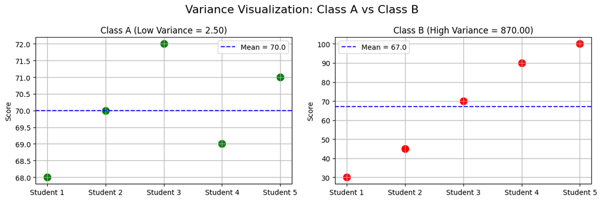

```python
# Plotting
fig, axs = plt.subplots(1, 2, figsize=(12, 4))

# Class A - Low Variance
axs[0].scatter(range(len(scores_A)), scores_A, color='green', s=100)
axs[0].axhline(mean_A, color='blue', linestyle='--', label=f"Mean = {mean_A:.1f}")
axs[0].set_title(f"Class A (Low Variance = {var_A:.2f})")
axs[0].set_ylabel("Score")
axs[0].set_xticks(range(len(scores_A)))
axs[0].set_xticklabels([f"Student {i+1}" for i in range(len(scores_A))])
axs[0].legend()
axs[0].grid()

# Class B - High Variance
axs[1].scatter(range(len(scores_B)), scores_B, color='red', s=100)
axs[1].axhline(mean_B, color='blue', linestyle='--', label=f"Mean = {mean_B:.1f}")
axs[1].set_title(f"Class B (High Variance = {var_B:.2f})")
axs[1].set_ylabel("Score")
axs[1].set_xticks(range(len(scores_B)))
axs[1].set_xticklabels([f"Student {i+1}" for i in range(len(scores_B))])
axs[1].legend()
axs[1].grid()

plt.suptitle("Variance Visualization: Class A vs Class B", fontsize=16)
plt.tight_layout()
plt.show()
```

- Variance ka matlab hota hai ke data values apne mean (average) ke ird gird kitni spread hui hain
- agar sab values ek dusre ke qareeb hoon to variance low hota hai (matlab data stable hai),
- aur agar values mean se door door hoon to variance high hota hai (data inconsistent ya bikhra hua hai).
- Low variance tab acha hota hai jab tum consistent result chahte ho — jaise students ka test score similar ho, sensor stable reading de, ya product size uniform ho.
- Lekin machine learning mein kabhi high variance bhi useful hoti hai — jaise feature selection mein (PCA), jahan zyada variation wale features model ke liye informative hote hain.
- Agar model predictions bohot fluctuate karein to high variance harmful hoti hai (overfitting ka signal)

3 Standard Deviation (“Variance ka square root”):

- Ye batata hai ke data average se kitna spread out hai; original units mein

[figure not shown]

```python
data = [4, 7, 2, 9, 12]
data
```

```
[4, 7, 2, 9, 12]
```

```python
x = 0
for i in data:
    x += i

mean = x / len(data)
mean
```

```
6.8
```

```python
x = 0
for i in data:
    x += (i-mean)**2
x
```

```
62.8
```

```python
pop_sd = (1/len(data) * x) ** 0.5
pop_sd
```

```
3.54400902933387
```

```python
sample_sd = (1/(len(data)-1) * x) ** 0.5
sample_sd
```

```
3.96232255123179
```

Standard Deviation for Group Data

[figure not shown]

```python
import pandas as pd
import numpy as np

df = pd.DataFrame({
    "f": [3, 4, 3],
    "x": [5, 15, 25]
})

df["fx"] = df["f"] * df["x"]
df["fx2"] = df["f"] * df["x"]**2

df
```

|  | f | x | fx | fx2 |
| --- | --- | --- | --- | --- |
| 0 | 3 | 5 | 15 | 75 |
| 1 | 4 | 15 | 60 | 900 |
| 2 | 3 | 25 | 75 | 1875 |

```python
n = df["f"].sum()
print(n)
```

```
10
```

```python
mean = df["fx"].sum() / n
print(mean)
```

```
15.0
```

```python
pop_var = df["fx2"].sum() / n - mean**2
print(pop_var)
```

```
60.0
```

```python
pop_sd = np.sqrt(pop_var)
print(pop_sd)
```

```
7.745966692414834
```

```python
sample_var = (n / (n - 1)) * pop_var
print(sample_var)
```

```
66.66666666666667
```

```python
sample_sd = np.sqrt(sample_var)
print(sample_sd)
```

```
8.16496580927726
```

## -> Standard Deviation Example

```python
scores_low_sd = [48, 49, 50, 51, 52]
scores_high_sd = [20, 35, 50, 65, 80]

mean_low = np.mean(scores_low_sd)
mean_high = np.mean(scores_high_sd)

std_low = np.std(scores_low_sd, ddof=1)
std_high = np.std(scores_high_sd, ddof=1)
```

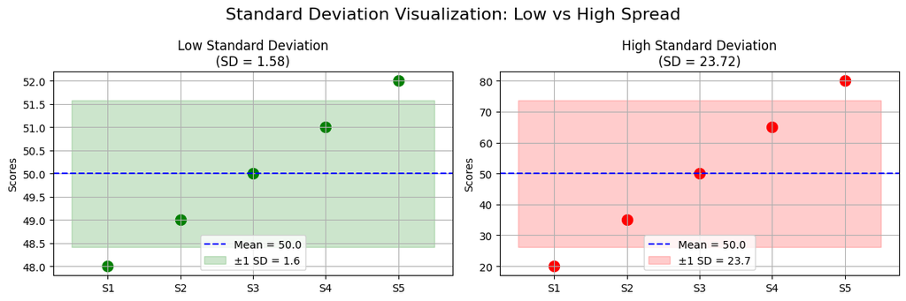

```python
# Plotting
fig, axs = plt.subplots(1, 2, figsize=(12, 4))

# Low SD
axs[0].scatter(range(len(scores_low_sd)), scores_low_sd, color='green', s=100)
axs[0].axhline(mean_low, color='blue', linestyle='--', label=f"Mean = {mean_low:.1f}")
axs[0].fill_between([-0.5, 4.5], mean_low - std_low, mean_low + std_low, color='green', alpha=0.2, label=f"±1 SD = {std_low:.1f}")
axs[0].set_title(f"Low Standard Deviation\n(SD = {std_low:.2f})")
axs[0].set_ylabel("Scores")
axs[0].set_xticks(range(len(scores_low_sd)))
axs[0].set_xticklabels([f"S{i+1}" for i in range(len(scores_low_sd))])
axs[0].legend()
axs[0].grid()

# High SD
axs[1].scatter(range(len(scores_high_sd)), scores_high_sd, color='red', s=100)
axs[1].axhline(mean_high, color='blue', linestyle='--', label=f"Mean = {mean_high:.1f}")
axs[1].fill_between([-0.5, 4.5], mean_high - std_high, mean_high + std_high, color='red', alpha=0.2, label=f"±1 SD = {std_high:.1f}")
axs[1].set_title(f"High Standard Deviation\n(SD = {std_high:.2f})")
axs[1].set_ylabel("Scores")
axs[1].set_xticks(range(len(scores_high_sd)))
axs[1].set_xticklabels([f"S{i+1}" for i in range(len(scores_high_sd))])
axs[1].legend()
axs[1].grid()

plt.suptitle("Standard Deviation Visualization: Low vs High Spread", fontsize=16)
plt.tight_layout()
plt.show()
```

**Standard Deviation (SD)** ek measure hai jo batata hai ke data values apne average (mean) se "kitni door" hain

4 Coefficient of Variation:

- Coefficient of Variation batata hai ke standard deviation mean ke comparison mein kitni zyada ya kam hai
- Yeh ek relative measure hota hai — % form mein express hota ha

| Scenario |
| --- |
| Jab 2 alag-alag datasets ka **spread compare** karna ho |
| Jab values **different units** ya **scales** mein hon |
| Machine Learning mein **feature variability** check karni ho |

```python
data = [4, 7, 2, 9, 12]
data
```

```
[4, 7, 2, 9, 12]
```

```python
x = 0
for i in data:
    x += i

mean = x / len(data)
mean
```

```
6.8
```

```python
x = 0
for i in data:
    x += (i-mean)**2
x
```

```
62.8
```

```python
sd = (1/(len(data)-1) * x) ** 0.5
sd
```

```
3.96232255123179
```

```python
cv = sd/mean * 100
cv
```

```
58.26944928282044
```

Coefficient of Variation of group Data

[figure not shown]

```python
df = pd.DataFrame({
    "f": [3, 4, 3],
    "x": [5, 15, 25]
})

df["fx"] = df["f"] * df["x"]
df["fx2"] = df["f"] * df["x"]**2

df
```

|  | f | x | fx | fx2 |
| --- | --- | --- | --- | --- |
| 0 | 3 | 5 | 15 | 75 |
| 1 | 4 | 15 | 60 | 900 |
| 2 | 3 | 25 | 75 | 1875 |

```python
n = df["f"].sum()
print(n)
```

```
10
```

```python
mean = df["fx"].sum() / n
print(mean)
```

```
15.0
```

```python
pop_var = df["fx2"].sum() / n - mean**2
print(pop_var)
```

```
60.0
```

```python
sample_var = (n / (n - 1)) * pop_var
print(sample_var)
```

```
66.66666666666667
```

```python
sample_sd = np.sqrt(sample_var)
print(sample_sd)
```

```
8.16496580927726
```

```python
cv = (sample_sd / mean) * 100
print(cv)
```

```
54.433105395181734
```

## -> Coefficient of Variation Example

```python
scores_class1 = [40, 50, 60, 50, 50]  # Mean ≈ 50
scores_class2 = [70, 80, 90, 80, 80]  # Mean ≈ 80

# Mean & Standard Deviation
mean1 = np.mean(scores_class1)
mean2 = np.mean(scores_class2)
std1 = np.std(scores_class1, ddof=1)
std2 = np.std(scores_class2, ddof=1)

# Coefficient of Variation (CV)
cv1 = (std1 / mean1) * 100
cv2 = (std2 / mean2) * 100
```

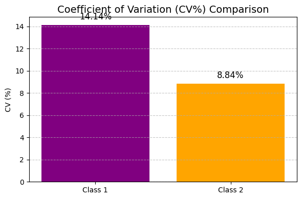

```python
# Plot CV Comparison using bar chart
fig, ax = plt.subplots(figsize=(6, 4))
bars = ax.bar(["Class 1", "Class 2"], [cv1, cv2], color=["purple", "orange"])

# Annotate bars with CV%
for bar in bars:
    height = bar.get_height()
    ax.annotate(f"{height:.2f}%",
                xy=(bar.get_x() + bar.get_width() / 2, height),
                xytext=(0, 5),
                textcoords="offset points",
                ha='center', va='bottom', fontsize=12)

# Axis labels and title
ax.set_title("Coefficient of Variation (CV%) Comparison", fontsize=14)
ax.set_ylabel("CV (%)")
ax.grid(True, axis='y', linestyle='--', alpha=0.7)

plt.tight_layout()
plt.show()
```

- Bar chart ne clearly dikhaya ke **Class 1 ka Coefficient of Variation (CV) 14.14%** tha
- jabke **Class 2 ka sirf 8.84%**. Dono classes ka standard deviation lagbhag same tha (≈7.07), lekin unka **mean alag tha**
- Class 1 ka mean 50 tha aur Class 2 ka mean 80.
- CV isliye important hai kyunke ye batata hai ke **data mean ke muqablay mein kitna vary karta hai**, yani **relative variation**.
- Yahan Class 1 ka CV zyada aaya, iska matlab hai ke uske scores mean ke muqablay mein **zyada spread** hain (inconsistent performance).
- Class 2 ka CV kam hai, matlab **uske scores zyada stable aur mean ke qareeb hain**.
- Graph visually yeh batata hai ke **CV ka use tab zaroori hota hai jab hum alag means ke datasets compare karte hain**, kyunke sirf standard deviation dekhna misleading ho sakta hai.